# Embarassment Analysis Update/Chaperone Analysis

Juanshu Wu

5/16/2021

#Data Wrangling

```r
library(tidyverse)
Dat <- read.csv("Prolific-500participants-Numeric.csv",TRUE)
Dat1 <- Dat %>% filter(Consent == "1")
STRANGE <- Dat1 %>% filter(is.na(Attention1))
#Delete the participants' data that fail the attention checks
Dat_attention_check_passed <- Dat1 %>% filter(Attention1 == 1)
Dat_attention_check_failed <- Dat1 %>% filter(Attention1 != 1)
type_gender_know <- Dat_attention_check_passed %>% select(Gender, Prolific.ID, starts_with(c("Body","Judgment")))
#type_gender_know <-
  #type_gender_know %>%
 # rename(Body.Naked_1 = Body.Naked._1, Body.Naked_2 = Body.Naked._2)
test <- type_gender_know %>% select(Gender, Body.Bowel_1, Body.Bowel_2)

test %>% pivot_longer(cols=c(Body.Bowel_1, Body.Bowel_2), names_to = "doctor_type", values_to = "scores", names_prefix="Body.Bowel_")
```

```
## # A tibble: 988 x 3
##    Gender doctor_type scores
##     <int> <chr>        <int>
##  1      2 1                6
##  2      2 2                4
##  3      2 1                2
##  4      2 2                2
##  5      2 1                3
##  6      2 2                6
##  7      2 1                5
##  8      2 2                5
##  9      2 1                4
## 10      2 2                3
## # ... with 978 more rows
```

```r
repeated_ready1 <-
type_gender_know %>%
  pivot_longer(cols = starts_with(c("Judgment", "Body")),
                 values_to = "scores",
                 names_to = (c("Type", "Sub", "Doctor")),
               names_pattern = c("(.*)\\.(.*)_(.)"))
```

#1.was this physician you’d seen before-> did you misrepresent…?

```r
DataA1 <- Dat_attention_check_passed %>% filter(Mispresent != 3 & Physician.Previous != 3)
DataA1$Mispresent = recode_factor(DataA1$Mispresent, "1" = "Misrepresent-Yes","2" = "Misrepresent-NO")
DataA1$Physician.Previous = recode_factor(DataA1$Physician.Previous, "1" = "PreviousSeenPhysician-Yes","2" = "PreviousSeenPhysician-No")
table(DataA1$Physician.Previous,DataA1$Mispresent)
```

```
##
##                             Misrepresent-Yes Misrepresent-NO
##   PreviousSeenPhysician-Yes               29             249
##   PreviousSeenPhysician-No                 7              97
```

```r
chisq.test(DataA1$Physician.Previous,DataA1$Mispresent)
```

```
##
##  Pearson's Chi-squared test with Yates' continuity correction
##
## data:  DataA1$Physician.Previous and DataA1$Mispresent
## X-squared = 0.81957, df = 1, p-value = 0.3653
```

Whether the physician is someone the participant had seen before does not significantly predict people misrepresent unfavorable information: Chisq(1) = 0.81957,p-value = 0.3653

#2.Gender-PT (patient) X gender-doc -> how much embar or awkwardness…?

```r
DataA2 <- Dat_attention_check_passed %>% filter(Physician.Gender != 3)
DataA2$Gender = recode_factor(DataA2$Gender, "1"= "Male","2" = "Female")
DataA2$Physician.Gender= recode_factor(DataA2$Physician.Gender, "1" = "Male", "2" = "Female")

A2.1 <- lm(BodilyEmbarrassment~ Physician.Gender+Gender, data = DataA2 )
A2.2<- lm(BodilyEmbarrassment ~ Physician.Gender+Gender+Physician.Gender:Gender,data = DataA2)

anova(A2.1)
```

```
## Analysis of Variance Table
##
## Response: BodilyEmbarrassment
##                   Df Sum Sq Mean Sq F value  Pr(>F)
## Physician.Gender   1   0.38  0.3756  0.0703 0.79135
## Gender             1  22.07 22.0745  4.1289 0.04397 *
## Residuals        146 780.56  5.3463
## ---
## Signif. codes:  0 '***' 0.001 '**' 0.01 '*' 0.05 '.' 0.1 ' ' 1
```

```r
anova(A2.1,A2.2)
```

```
## Analysis of Variance Table
##
## Model 1: BodilyEmbarrassment ~ Physician.Gender + Gender
## Model 2: BodilyEmbarrassment ~ Physician.Gender + Gender + Physician.Gender:Gender
##   Res.Df    RSS Df Sum of Sq      F Pr(>F)
## 1    146 780.56
## 2    145 780.29  1    0.2676 0.0497 0.8239
```

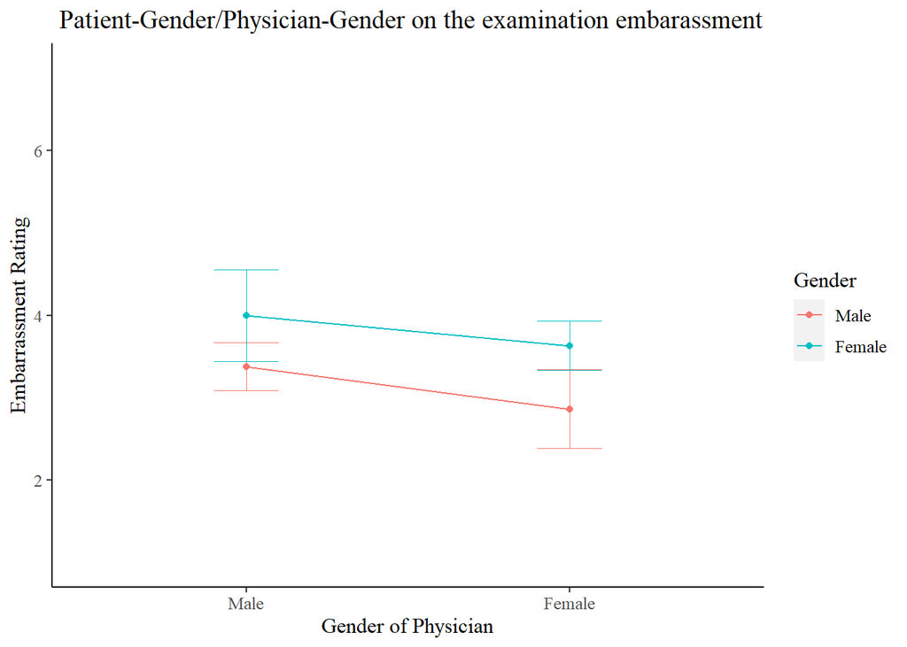

```r
DataA2 %>% ggplot() +
aes(x = Physician.Gender, color = Gender, group = Gender, y = BodilyEmbarrassment) +
stat_summary(fun.y = mean, geom = "point") +
stat_summary(fun.y = mean, geom = "line")+
labs(y = "Embarrassment Rating", x = "Gender of Physician")+
theme (plot.title = element_text(hjust = 0.5), text = element_text(family = "serif", size = 12), panel.grid.major = element_blank(), panel.grid.minor = element_blank(),panel.background = element_blank(), axis.line = element_line(colour = "black"))+
ggtitle(" Patient-Gender/Physician-Gender on the examination embarassment")+
stat_summary(fun.data = "mean_se",geom = "errorbar", size = 0.05,width = 0.2)+
scale_y_continuous(limits = c(1, 7))
```

Adding the interaction of the Gender-PT (patient) X gender-doc does not significanly improves the model or in other words does not explain more variance regarding how much embar or awkwardness of the private test: F(1,145)= 0.0497, p = 0.8239. There is a main effect Participant’s Gender on reported embarassment : F(1,146)= 4.13,p = 0.044 ;but there is no main effect of Physicain Gender on reported embarassment: F(1,146)= 0.07, p = 0.79

#3.Gender-PT X gender-doc -> were your private parts examined.

```r
library(tidyverse)
DataA3 <- Dat_attention_check_passed %>% filter(Physician.Gender != 3 & ExaminePrivate != 3)
DataA3$ExaminePrivate = recode_factor(DataA3$ExaminePrivate, "1" = "1","2" = "0")
DataA3$Gender = recode_factor(DataA3$Gender, "1"= "Male","2" = "Female")
DataA3$Physician.Gender= recode_factor(DataA3$Physician.Gender, "1" = "Male", "2" = "Female")
A3.1<- glm(formula = ExaminePrivate~ Physician.Gender+Gender, family = "binomial",data = DataA3)
A3.2 <- glm(formula = ExaminePrivate~ Physician.Gender*Gender, family = "binomial",data = DataA3)
summary(A3.1)
```

```
##
## Call:
## glm(formula = ExaminePrivate ~ Physician.Gender + Gender, family = "binomial",
##     data = DataA3)
##
## Deviance Residuals:
##     Min       1Q   Median       3Q      Max
## -1.5242  -1.3734   0.8665   0.9933   1.1133
##
## Coefficients:
##                        Estimate Std. Error z value Pr(>|z|)
## (Intercept)              0.4498     0.1677   2.683   0.0073 **
## Physician.GenderFemale  -0.2972     0.2191  -1.356   0.1750
## GenderFemale             0.3363     0.2191   1.535   0.1248
## ---
## Signif. codes:  0 '***' 0.001 '**' 0.01 '*' 0.05 '.' 0.1 ' ' 1
##
## (Dispersion parameter for binomial family taken to be 1)
##
##     Null deviance: 517.78  on 388  degrees of freedom
## Residual deviance: 514.49  on 386  degrees of freedom
## AIC: 520.49
##
## Number of Fisher Scoring iterations: 4
```

```r
#Model Comparison
anova(A3.1,A3.2,test = "Chisq")
```

```
## Analysis of Deviance Table
##
## Model 1: ExaminePrivate ~ Physician.Gender + Gender
## Model 2: ExaminePrivate ~ Physician.Gender * Gender
##   Resid. Df Resid. Dev Df Deviance Pr(>Chi)
## 1       386     514.49
## 2       385     507.21  1   7.2815 0.006967 **
## ---
## Signif. codes:  0 '***' 0.001 '**' 0.01 '*' 0.05 '.' 0.1 ' ' 1
```

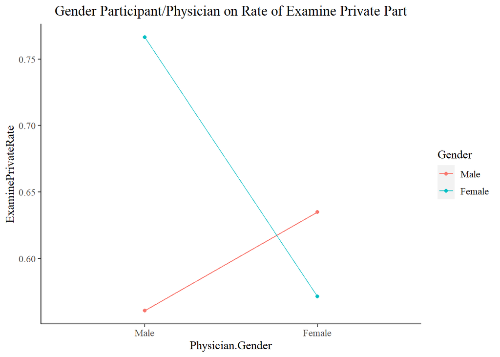

```r
DataA3$ExaminePrivate = as.numeric(DataA3$ExaminePrivate)

Pivot1 = DataA3 %>%group_by(Physician.Gender,Gender) %>% summarise(ExaminePrivateRate = mean(ExaminePrivate)-1)

Pivot1%>% ggplot()+aes(x= Physician.Gender,group =Gender,color = Gender,y= ExaminePrivateRate)+
geom_point()+
geom_line()+
theme (plot.title = element_text(hjust = 0.5), text = element_text(family = "serif", size = 12), panel.grid.major = element_blank(), panel.grid.minor = element_blank(),panel.background = element_blank(), axis.line = element_line(colour = "black"))+
ggtitle("Gender Participant/Physician on Rate of Examine Private Part")
```

There is a significant interaction of Physician.Gender and Participant Gender in predicting whether the private part is examined. Chisq(1,385) = 7.28, p = 0.006

#4.Gender-pt X gender-doc -> chaperone present

```r
DataA4 <- Dat_attention_check_passed %>% filter(Physician.Gender != 3 & ExaminePrivate != 3 &Chaperone.Presence != 5)
DataA4$Gender = recode_factor(DataA4$Gender, "1"= "Male","2" = "Female")
DataA4$Physician.Gender= recode_factor(DataA4$Physician.Gender, "1" = "Male", "2" = "Female")
DataA4$Chaperone.Presence = recode_factor(DataA4$Chaperone.Presence, "1" = "0", "2" = "1", "4" = "1")

A4.1<- glm(formula = Chaperone.Presence~ Physician.Gender+Gender, family = "binomial",data = DataA4)
A4.2 <- glm(formula = Chaperone.Presence~ Physician.Gender*Gender, family = "binomial",data = DataA4)

summary(A4.1)
```

```
##
## Call:
## glm(formula = Chaperone.Presence ~ Physician.Gender + Gender,
##     family = "binomial", data = DataA4)
##
## Deviance Residuals:
##     Min       1Q   Median       3Q      Max
## -0.8285  -0.7115  -0.4630  -0.3914   2.2836
##
## Coefficients:
##                        Estimate Std. Error z value Pr(>|z|)
## (Intercept)             -2.1790     0.2666  -8.173 3.00e-16 ***
## Physician.GenderFemale  -0.3518     0.2895  -1.216    0.224
## GenderFemale             1.2861     0.3170   4.058 4.96e-05 ***
## ---
## Signif. codes:  0 '***' 0.001 '**' 0.01 '*' 0.05 '.' 0.1 ' ' 1
##
## (Dispersion parameter for binomial family taken to be 1)
##
##     Null deviance: 351.26  on 380  degrees of freedom
## Residual deviance: 332.88  on 378  degrees of freedom
## AIC: 338.88
##
## Number of Fisher Scoring iterations: 5
```

```r
#Model Comparison
anova(A4.1,A4.2,test = "Chisq")
```

```
## Analysis of Deviance Table
##
## Model 1: Chaperone.Presence ~ Physician.Gender + Gender
## Model 2: Chaperone.Presence ~ Physician.Gender * Gender
##   Resid. Df Resid. Dev Df Deviance Pr(>Chi)
## 1       378     332.88
## 2       377     330.28  1   2.5981    0.107
```

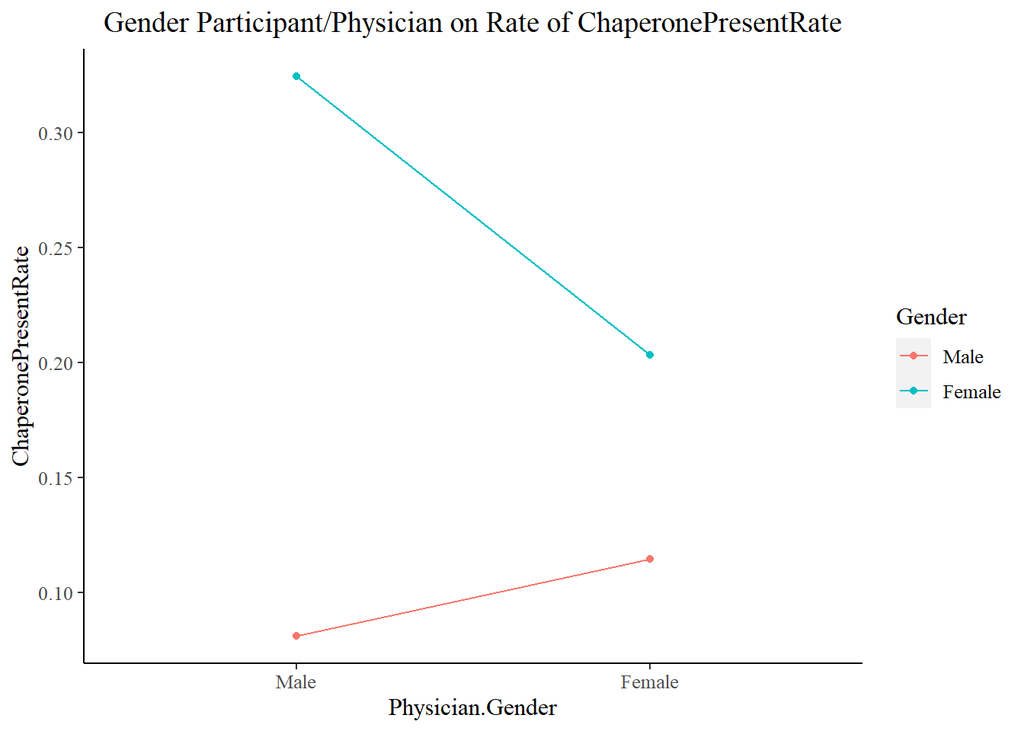

```r
DataA4$Chaperone.Presence = as.numeric(DataA4$Chaperone.Presence)

Pivot2 = DataA4 %>%group_by(Physician.Gender,Gender) %>% summarise(ChaperonePresentRate = mean(Chaperone.Presence)-1)

Pivot2%>% ggplot()+aes(x= Physician.Gender,group =Gender,color = Gender,y= ChaperonePresentRate)+
geom_point()+
geom_line()+
theme (plot.title = element_text(hjust = 0.5), text = element_text(family = "serif", size = 12), panel.grid.major = element_blank(), panel.grid.minor = element_blank(),panel.background = element_blank(), axis.line = element_line(colour = "black"))+
ggtitle("Gender Participant/Physician on Rate of ChaperonePresentRate")
```

There is NO significant interaction of Physician.Gender and Participant Gender in predicting whether the Chaperone is present. Chisq(1,377) = 2.598, p = 0.11

There is significant effect of Gender in predicting whether the Chaperone is present.Specifically, if the participant gender is Female, it will increase the log odd of the rate of Chaperone present by adding 1.3

#5.Distribution of DV responses on “What is your attitude… chaperone…?”

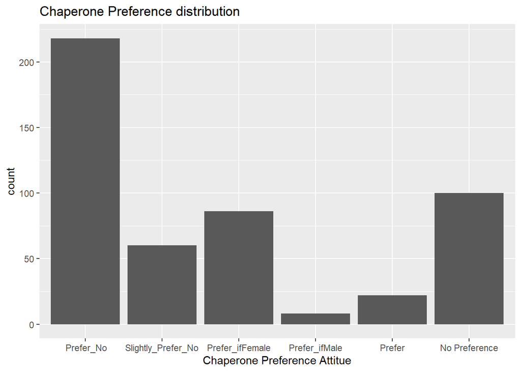

```r
DataA5 <- Dat_attention_check_passed %>% filter(Chaperone.Attitude!= "NA")
DataA5$Chaperone.Attitude = recode_factor(DataA5$Chaperone.Attitude, "1" = " Prefer_No", "2" = "Slightly_Prefer_No", "3" = "Prefer_ifFemale", "4" = "Prefer_ifMale", "5" = "Prefer" , "6" = "Prefer", "7" = "No Preference")

library(ggplot2)
library(dplyr)
data <- DataA5%>%
    group_by(Chaperone.Attitude) %>%
    summarise(count = n())

data %>%
    ggplot(aes(x = Chaperone.Attitude, y = count)) +
    geom_col()+labs(x = "Chaperone Preference Attitue")+ggtitle("Chaperone Preference distribution" )
```

#6.Gender-pt -> gender of chaperone present

```r
DataA6 <- Dat_attention_check_passed %>% filter(Chaperone.Presence!= 1 &Chaperone.Presence!= 5)
DataA6$Chaperone.Present.Gender = recode_factor(DataA6$Chaperone.Presence, "2" = "Chaperone -Female", "4" = "Chaperone-Male")
DataA6$Gender = recode_factor(DataA6$Gender, "1" = "Participant-Male", "2" = "Participant-Female")

table(DataA6$Chaperone.Present.Gender,DataA6$Gender)
```

```
##
##                     Participant-Male Participant-Female
##   Chaperone -Female               12                 48
##   Chaperone-Male                   5                  2
```

```r
chisq.test(DataA6$Physician.Previous,DataA6$Gender)
```

```
##
##  Pearson's Chi-squared test with Yates' continuity correction
##
## data:  DataA6$Physician.Previous and DataA6$Gender
## X-squared = 0.039431, df = 1, p-value = 0.8426
```

#7.Gender-pt -> chaperone was present

```r
DataA7 <- Dat_attention_check_passed %>% filter(ExaminePrivate != 3 &Chaperone.Presence != 5)
DataA7$Gender = recode_factor(DataA7$Gender, "1"= "Male","2" = "Female")
DataA7$Chaperone.Presence = recode_factor(DataA7$Chaperone.Presence, "1" = "NO Chaperone", "2" = "Chaperone Present", "4" = "Chaperone Present")

table(DataA7$Chaperone.Presence,DataA7$Gender)
```

```
##
##                     Male Female
##   NO Chaperone       167    149
##   Chaperone Present   17     50
```

```r
chisq.test(DataA7$Chaperone.Presence,DataA7$Gender)
```

```
##
##  Pearson's Chi-squared test with Yates' continuity correction
##
## data:  DataA7$Chaperone.Presence and DataA7$Gender
## X-squared = 15.635, df = 1, p-value = 7.683e-05
```

The Participant Gender significantly predict the Prescence of chaperone.X-squared (1)= 15.6, p-value <= 0.01